# CSA RQ1

Yosta Rambu Lika Enga

2025-02-14

```r
library(tidyverse)
library(stargazer)
```

```r
library(lubridate)
library(dplyr)
library(tidyr)
library(tibble)
library(ggplot2)
library(stringr)
```

## Here are URL for my Github folder that includes CSA files.

```r
# URL for CSA files
# Member: https://raw.githubusercontent.com/ykimasu/PAF540_CSA/refs/heads/main/SIM-2574_member.csv
# Members (cleaned): https://raw.githubusercontent.com/ykimasu/PAF540_CSA/refs/heads/main/SIM-2574_member_clean.csv
# Empl: https://raw.githubusercontent.com/ykimasu/PAF540_CSA/refs/heads/main/SIM-2574_emp.csv
# Salary: https://raw.githubusercontent.com/ykimasu/PAF540_CSA/refs/heads/main/SIM-2574_salary.csv
# Salary (cleaned): https://raw.githubusercontent.com/ykimasu/PAF540_CSA/refs/heads/main/SIM-2574_salary_clean.csv
# Empl_status: https://raw.githubusercontent.com/ykimasu/PAF540_CSA/refs/heads/main/SIM-2574_emp_status.csv
# Status_ref: https://raw.githubusercontent.com/ykimasu/PAF540_CSA/refs/heads/main/SIM-2574_status_ref.csv
# Baseline: https://raw.githubusercontent.com/ykimasu/PAF540_CSA/refs/heads/main/SIM-2574_baseline.csv
# Employer_characteristics: https://raw.githubusercontent.com/ykimasu/PAF540_CSA/refs/heads/main/SIM-2574-%20Employer%20Characteristics.csv
# County_characteristics: https://raw.githubusercontent.com/ykimasu/PAF540_CSA/refs/heads/main/SIM-2574-%20County%20Characteristics.csv

# Members (cleaned) and Salary (cleaned) are the files that I removed outliters.
# Members (cleaned): I removed 21 observations that the year of birth are after 2012
# Salry (cleaned): I removed 23 observations that have negative pensionable salary and 4 observations that are greater than $35,000.

# read in data
URL1 <- "https://raw.githubusercontent.com/ykimasu/PAF540_CSA/refs/heads/main/SIM-2574_member_clean.csv"
member <- read.csv(URL1)

URL2 <- "https://raw.githubusercontent.com/ykimasu/PAF540_CSA/refs/heads/main/SIM-2574_emp.csv"
empl <- read.csv(URL2)
view(URL2)

URL3 <- "https://raw.githubusercontent.com/ykimasu/PAF540_CSA/refs/heads/main/SIM-2574_salary_clean.csv"
salary <- read.csv(URL3)

# you can add more here....
```

On the right top, there are Data panel where you can see the three data file you imported. Check the number of observation

We will work with the empl file below

## Retirement plans

Let’s start with the retirement plan variable. What plans are included? We keep only observations in the employment dataset that are defined benefit (CORP) and defined contribution (CODC) plans. How many observations are left in the dataset?

```r
plan_table <- empl %>%
  count(pln_acronym)

print(plan_table)
```

```
##   pln_acronym     n
## 1        CODC 11379
## 2        CORP 18593
## 3        PSDC   458
## 4       PSPRS 34768
```

Subset only those members that have CORP and CODC.

```r
# We will not use this subset code unless we need it.
summary(empl)
```

```
##       m_id            me_id        employer_name      pln_acronym
##  Min.   :     2   Min.   :124681   Length:65198       Length:65198
##  1st Qu.: 33516   1st Qu.:163701   Class :character   Class :character
##  Median : 66763   Median :202688   Mode  :character   Mode  :character
##  Mean   : 76293   Mean   :202928
##  3rd Qu.: 99960   3rd Qu.:241592
##  Max.   :278392   Max.   :283940
##
##     tier_no        hire_dt            term_dt          total_service
##  Min.   :0.000   Length:65198       Length:65198       Min.   : 0.000
##  1st Qu.:1.000   Class :character   Class :character   1st Qu.: 2.204
##  Median :2.000   Mode  :character   Mode  :character   Median : 7.105
##  Mean   :1.972                                         Mean   : 9.900
##  3rd Qu.:3.000                                         3rd Qu.:17.681
##  Max.   :3.000                                         Max.   :47.968
##                                                        NA's   :2612
```

```r
employment <- subset(empl, pln_acronym == "CODC" | pln_acronym == "CORP" )
summary(employment)
```

```
##       m_id            me_id        employer_name      pln_acronym
##  Min.   :     2   Min.   :124684   Length:29972       Length:29972
##  1st Qu.: 34244   1st Qu.:164346   Class :character   Class :character
##  Median : 67938   Median :203672   Mode  :character   Mode  :character
##  Mean   : 79553   Mean   :203772
##  3rd Qu.:101500   3rd Qu.:242626
##  Max.   :278392   Max.   :283939
##
##     tier_no        hire_dt            term_dt          total_service
##  Min.   :0.000   Length:29972       Length:29972       Min.   : 0.000
##  1st Qu.:1.000   Class :character   Class :character   1st Qu.: 1.467
##  Median :2.000   Mode  :character   Mode  :character   Median : 4.611
##  Mean   :2.118                                         Mean   : 7.606
##  3rd Qu.:3.000                                         3rd Qu.:12.068
##  Max.   :3.000                                         Max.   :47.968
##                                                        NA's   :1274
```

```r
plan_table <- employment %>%
  count(pln_acronym)

print(plan_table)
```

```
##   pln_acronym     n
## 1        CODC 11379
## 2        CORP 18593
```

## Tiers

Look at the tier_no variable. See the project overview - data dictionary

```r
tier_table <- employment %>%
  count(tier_no)

print(tier_table)
```

```
##   tier_no     n
## 1       0   188
## 2       1  8331
## 3       2  9206
## 4       3 12247
```

```r
summary(employment)
```

```
##       m_id            me_id        employer_name      pln_acronym
##  Min.   :     2   Min.   :124684   Length:29972       Length:29972
##  1st Qu.: 34244   1st Qu.:164346   Class :character   Class :character
##  Median : 67938   Median :203672   Mode  :character   Mode  :character
##  Mean   : 79553   Mean   :203772
##  3rd Qu.:101500   3rd Qu.:242626
##  Max.   :278392   Max.   :283939
##
##     tier_no        hire_dt            term_dt          total_service
##  Min.   :0.000   Length:29972       Length:29972       Min.   : 0.000
##  1st Qu.:1.000   Class :character   Class :character   1st Qu.: 1.467
##  Median :2.000   Mode  :character   Mode  :character   Median : 4.611
##  Mean   :2.118                                         Mean   : 7.606
##  3rd Qu.:3.000                                         3rd Qu.:12.068
##  Max.   :3.000                                         Max.   :47.968
##                                                        NA's   :1274
```

## hire_dt

```r
employment$hire_yr <- year(employment$hire_dt)
summary(employment)
```

```
##       m_id            me_id        employer_name      pln_acronym
##  Min.   :     2   Min.   :124684   Length:29972       Length:29972
##  1st Qu.: 34244   1st Qu.:164346   Class :character   Class :character
##  Median : 67938   Median :203672   Mode  :character   Mode  :character
##  Mean   : 79553   Mean   :203772
##  3rd Qu.:101500   3rd Qu.:242626
##  Max.   :278392   Max.   :283939
##
##     tier_no        hire_dt            term_dt          total_service
##  Min.   :0.000   Length:29972       Length:29972       Min.   : 0.000
##  1st Qu.:1.000   Class :character   Class :character   1st Qu.: 1.467
##  Median :2.000   Mode  :character   Mode  :character   Median : 4.611
##  Mean   :2.118                                         Mean   : 7.606
##  3rd Qu.:3.000                                         3rd Qu.:12.068
##  Max.   :3.000                                         Max.   :47.968
##                                                        NA's   :1274
##     hire_yr
##  Min.   :1976
##  1st Qu.:2011
##  Median :2017
##  Mean   :2015
##  3rd Qu.:2020
##  Max.   :2024
##
```

## Employer_name

I am going to create a duplicate column of employer_name for future use.

```r
employment <- employment %>%
  mutate(employer_name_duplicate = employer_name)
summary (employment)
```

```
##       m_id            me_id        employer_name      pln_acronym
##  Min.   :     2   Min.   :124684   Length:29972       Length:29972
##  1st Qu.: 34244   1st Qu.:164346   Class :character   Class :character
##  Median : 67938   Median :203672   Mode  :character   Mode  :character
##  Mean   : 79553   Mean   :203772
##  3rd Qu.:101500   3rd Qu.:242626
##  Max.   :278392   Max.   :283939
##
##     tier_no        hire_dt            term_dt          total_service
##  Min.   :0.000   Length:29972       Length:29972       Min.   : 0.000
##  1st Qu.:1.000   Class :character   Class :character   1st Qu.: 1.467
##  Median :2.000   Mode  :character   Mode  :character   Median : 4.611
##  Mean   :2.118                                         Mean   : 7.606
##  3rd Qu.:3.000                                         3rd Qu.:12.068
##  Max.   :3.000                                         Max.   :47.968
##                                                        NA's   :1274
##     hire_yr     employer_name_duplicate
##  Min.   :1976   Length:29972
##  1st Qu.:2011   Class :character
##  Median :2017   Mode  :character
##  Mean   :2015
##  3rd Qu.:2020
##  Max.   :2024
##
```

We will check how many agencies remained in the dataset and the number of observations for each employer. There are 43 rows in the frequency table

```r
employment %>%
  count(employer_name)
```

```
##                        employer_name     n
## 1                APACHE COUNTY - AOC    39
## 2               APACHE COUNTY - CORP    94
## 3       CITY OF AVONDALE - DETENTION    32
## 4     CITY OF SOMERTON - DISPATCHERS     5
## 5               COCHISE COUNTY - AOC   129
## 6              COCHISE COUNTY - CORP   177
## 7              COCONINO COUNTY - AOC   179
## 8             COCONINO COUNTY - CORP   242
## 9   DEPARTMENT OF CORRECTIONS - CORP 16818
## 10 DEPT OF JUVENILE CORRECTIONS-CORP  1082
## 11  DEPT. OF PUBLIC SAFETY DETENTION    19
## 12 DEPT. OF PUBLIC SAFETY DISPATCHER    30
## 13                 GILA COUNTY - AOC    52
## 14                GILA COUNTY - CORP   149
```

[output cut: 29 more lines]

```r
# I downloaed the table as a csv file to examine the name.
write.csv(employment, "employer_name.csv", row.names = FALSE)
```

We need to do some data cleaning processes for the Employer Name variable:

1. Remove agencies with AOC as part of the employer name.

```r
employment <- employment %>%
  filter(!str_detect(employer_name, "- AOC"))

employment <- employment %>%
  filter(!str_detect(employer_name, "-AOC JUDICIAL BR."))

employment <- employment %>%
  filter(!str_detect(employer_name, " (AOC)"))

summary(employment)
```

```
##       m_id            me_id        employer_name      pln_acronym
##  Min.   :     2   Min.   :124690   Length:25432       Length:25432
##  1st Qu.: 34165   1st Qu.:164513   Class :character   Class :character
##  Median : 67941   Median :203625   Mode  :character   Mode  :character
##  Mean   : 79518   Mean   :203703
##  3rd Qu.:101609   3rd Qu.:242394
##  Max.   :278389   Max.   :283934
##
##     tier_no        hire_dt            term_dt          total_service
##  Min.   :0.000   Length:25432       Length:25432       Min.   : 0.000
##  1st Qu.:1.000   Class :character   Class :character   1st Qu.: 1.467
##  Median :2.000   Mode  :character   Mode  :character   Median : 4.534
##  Mean   :2.129                                         Mean   : 7.365
##  3rd Qu.:3.000                                         3rd Qu.:11.682
##  Max.   :3.000                                         Max.   :47.822
##                                                        NA's   :1118
##     hire_yr     employer_name_duplicate
##  Min.   :1976   Length:25432
##  1st Qu.:2011   Class :character
##  Median :2017   Mode  :character
##  Mean   :2015
##  3rd Qu.:2020
##  Max.   :2024
##
```

I also would like to remove STATE OF ARIZONA (AOC). How many agency remained?

```r
employment <- employment %>%
  filter(employer_name != "STATE OF ARIZONA (AOC)")
```

```r
employment %>%
  count(employer_name)
```

```
##                        employer_name     n
## 1               APACHE COUNTY - CORP    94
## 2       CITY OF AVONDALE - DETENTION    32
## 3     CITY OF SOMERTON - DISPATCHERS     5
## 4              COCHISE COUNTY - CORP   177
## 5             COCONINO COUNTY - CORP   242
## 6   DEPARTMENT OF CORRECTIONS - CORP 16818
## 7  DEPT OF JUVENILE CORRECTIONS-CORP  1082
## 8   DEPT. OF PUBLIC SAFETY DETENTION    19
## 9  DEPT. OF PUBLIC SAFETY DISPATCHER    30
## 10                GILA COUNTY - CORP   149
## 11         GILA COUNTY - DISPATCHERS     6
## 12         GRAHAM COUNTY - DETENTION   216
## 13       GRAHAM COUNTY - DISPATCHERS     6
## 14           LA PAZ COUNTY DETENTION    86
## 15            MARICOPA COUNTY - CORP  3186
## 16              MOHAVE COUNTY - CORP   376
## 17              NAVAJO COUNTY - CORP   153
## 18          ORO VALLEY - DISPATCHERS     4
## 19                PIMA COUNTY - CORP  1292
## 20               PINAL COUNTY - CORP   327
## 21        PINAL COUNTY - DISPATCHERS    11
## 22          SANTA CRUZ COUNTY - CORP   136
## 23      TOWN OF MARANA - DISPATCHERS     7
## 24    TOWN OF WICKENBURG-DISPATCHERS     3
## 25             YAVAPAI COUNTY - CORP   522
## 26      YAVAPAI COUNTY - DISPATCHERS     5
## 27                YUMA COUNTY - CORP   446
```

2. We will remove agency that has dispatchers. How many agency remained?

```r
employment <- employment %>%
  filter(!str_detect(employer_name, "DISPATCHERS"))

employment <- employment %>%
  filter(!str_detect(employer_name, "DEPT. OF PUBLIC SAFETY DISPATCHER"))

summary(employment)
```

```
##       m_id            me_id        employer_name      pln_acronym
##  Min.   :     2   Min.   :124690   Length:25353       Length:25353
##  1st Qu.: 34182   1st Qu.:164523   Class :character   Class :character
##  Median : 67944   Median :203655   Mode  :character   Mode  :character
##  Mean   : 79561   Mean   :203727
##  3rd Qu.:101598   3rd Qu.:242395
##  Max.   :278389   Max.   :283934
##
##     tier_no        hire_dt            term_dt          total_service
##  Min.   :0.000   Length:25353       Length:25353       Min.   : 0.000
##  1st Qu.:1.000   Class :character   Class :character   1st Qu.: 1.462
##  Median :2.000   Mode  :character   Mode  :character   Median : 4.517
##  Mean   :2.132                                         Mean   : 7.327
##  3rd Qu.:3.000                                         3rd Qu.:11.584
##  Max.   :3.000                                         Max.   :47.822
##                                                        NA's   :1118
##     hire_yr     employer_name_duplicate
##  Min.   :1976   Length:25353
##  1st Qu.:2011   Class :character
##  Median :2017   Mode  :character
##  Mean   :2015
##  3rd Qu.:2020
##  Max.   :2024
##
```

```r
employment %>%
  count(employer_name)
```

```
##                        employer_name     n
## 1               APACHE COUNTY - CORP    94
## 2       CITY OF AVONDALE - DETENTION    32
## 3              COCHISE COUNTY - CORP   177
## 4             COCONINO COUNTY - CORP   242
## 5   DEPARTMENT OF CORRECTIONS - CORP 16818
## 6  DEPT OF JUVENILE CORRECTIONS-CORP  1082
## 7   DEPT. OF PUBLIC SAFETY DETENTION    19
## 8                 GILA COUNTY - CORP   149
## 9          GRAHAM COUNTY - DETENTION   216
## 10           LA PAZ COUNTY DETENTION    86
## 11            MARICOPA COUNTY - CORP  3186
## 12              MOHAVE COUNTY - CORP   376
## 13              NAVAJO COUNTY - CORP   153
## 14                PIMA COUNTY - CORP  1292
## 15               PINAL COUNTY - CORP   327
## 16          SANTA CRUZ COUNTY - CORP   136
## 17             YAVAPAI COUNTY - CORP   522
## 18                YUMA COUNTY - CORP   446
```

3. I would like to remove - CORP, - DETENTION, ETC from the employer_name column. You can use the gsub() function in R to perform string replacement. Check the result using the code above.

```r
employment$employer_name <- gsub(" - CORP", "", employment$employer_name)
employment$employer_name <- gsub(" - DETENTION", "", employment$employer_name)
employment$employer_name <- gsub("-CORP", "", employment$employer_name)
employment$employer_name <- gsub(" DETENTION", "", employment$employer_name)
```

4. I would like to remove the period in the name of DEPT. OF PUBLIC SAFETY and rename it as DEPT OF PUBLIC SAFETY.

```r
employment$employer_name <- gsub("DEPT\\. OF PUBLIC SAFETY", "DEPT OF PUBLIC SAFETY", employment$employer_name)
```

```r
employment %>%
  count(employer_name)
```

```
##                   employer_name     n
## 1                 APACHE COUNTY    94
## 2              CITY OF AVONDALE    32
## 3                COCHISE COUNTY   177
## 4               COCONINO COUNTY   242
## 5     DEPARTMENT OF CORRECTIONS 16818
## 6  DEPT OF JUVENILE CORRECTIONS  1082
## 7         DEPT OF PUBLIC SAFETY    19
## 8                   GILA COUNTY   149
## 9                 GRAHAM COUNTY   216
## 10                LA PAZ COUNTY    86
## 11              MARICOPA COUNTY  3186
## 12                MOHAVE COUNTY   376
## 13                NAVAJO COUNTY   153
## 14                  PIMA COUNTY  1292
## 15                 PINAL COUNTY   327
## 16            SANTA CRUZ COUNTY   136
## 17               YAVAPAI COUNTY   522
## 18                  YUMA COUNTY   446
```

5. I would like to create a new column named “level” to show whether each agency is city, county, or state. You can create the new level column in your dataset using the dplyr package for conditional logic.

```r
employment <- employment %>%
  mutate(level = case_when(
    grepl("COUNTY", employer_name, ignore.case = TRUE) ~ "County",
    grepl("CITY", employer_name, ignore.case = TRUE) ~ "City",
    TRUE ~ "State"
  ))
```

```r
level_table <- employment %>%
  count(level)

print(level_table)
```

```
##    level     n
## 1   City    32
## 2 County  7402
## 3  State 17919
```

## combined_id

Create a new variable that combines m_id and me_id. Now You have three ID variables in your dataset: m_id, me_id, and combined_id. Once you create a combined_id, you can use any of the three unique ID, depending upon the situation.

Remember that unique employee ID (m_id) was assigned even if the same person worked at multiple agencies (me_id). If an employee worked the same agency more than once at different times, they will have a unique employee ID but different employer ID.

```r
employment$combined_id <- paste(employment$m_id, employment$me_id, sep = "-")
summary(employment)
```

```
##       m_id            me_id        employer_name      pln_acronym
##  Min.   :     2   Min.   :124690   Length:25353       Length:25353
##  1st Qu.: 34182   1st Qu.:164523   Class :character   Class :character
##  Median : 67944   Median :203655   Mode  :character   Mode  :character
##  Mean   : 79561   Mean   :203727
##  3rd Qu.:101598   3rd Qu.:242395
##  Max.   :278389   Max.   :283934
##
##     tier_no        hire_dt            term_dt          total_service
##  Min.   :0.000   Length:25353       Length:25353       Min.   : 0.000
##  1st Qu.:1.000   Class :character   Class :character   1st Qu.: 1.462
##  Median :2.000   Mode  :character   Mode  :character   Median : 4.517
##  Mean   :2.132                                         Mean   : 7.327
##  3rd Qu.:3.000                                         3rd Qu.:11.584
##  Max.   :3.000                                         Max.   :47.822
##                                                        NA's   :1118
##     hire_yr     employer_name_duplicate    level           combined_id
##  Min.   :1976   Length:25353            Length:25353       Length:25353
##  1st Qu.:2011   Class :character        Class :character   Class :character
##  Median :2017   Mode  :character        Mode  :character   Mode  :character
##  Mean   :2015
##  3rd Qu.:2020
##  Max.   :2024
##
```

## RQ1

```r
employment <- employment %>%
  filter(!str_detect(employer_name, "CITY OF AVONDALE"))
```

```r
employment <- employment %>%
  filter(!str_detect(employer_name, "CITY OF AVONDALE"))

summary(employment)
```

```
##       m_id            me_id        employer_name      pln_acronym
##  Min.   :     2   Min.   :124690   Length:25321       Length:25321
##  1st Qu.: 34177   1st Qu.:164523   Class :character   Class :character
##  Median : 67912   Median :203660   Mode  :character   Mode  :character
##  Mean   : 79552   Mean   :203720
##  3rd Qu.:101567   3rd Qu.:242392
##  Max.   :278389   Max.   :283934
##
##     tier_no        hire_dt            term_dt          total_service
##  Min.   :0.000   Length:25321       Length:25321       Min.   : 0.000
##  1st Qu.:1.000   Class :character   Class :character   1st Qu.: 1.459
##  Median :2.000   Mode  :character   Mode  :character   Median : 4.515
##  Mean   :2.133                                         Mean   : 7.326
##  3rd Qu.:3.000                                         3rd Qu.:11.584
##  Max.   :3.000                                         Max.   :47.822
##                                                        NA's   :1116
##     hire_yr     employer_name_duplicate    level           combined_id
##  Min.   :1976   Length:25321            Length:25321       Length:25321
##  1st Qu.:2011   Class :character        Class :character   Class :character
##  Median :2017   Mode  :character        Mode  :character   Mode  :character
##  Mean   :2015
##  3rd Qu.:2020
##  Max.   :2024
##
```

```r
employment %>%
  count(employer_name)
```

```
##                   employer_name     n
## 1                 APACHE COUNTY    94
## 2                COCHISE COUNTY   177
## 3               COCONINO COUNTY   242
## 4     DEPARTMENT OF CORRECTIONS 16818
## 5  DEPT OF JUVENILE CORRECTIONS  1082
## 6         DEPT OF PUBLIC SAFETY    19
## 7                   GILA COUNTY   149
## 8                 GRAHAM COUNTY   216
## 9                 LA PAZ COUNTY    86
## 10              MARICOPA COUNTY  3186
## 11                MOHAVE COUNTY   376
## 12                NAVAJO COUNTY   153
## 13                  PIMA COUNTY  1292
## 14                 PINAL COUNTY   327
## 15            SANTA CRUZ COUNTY   136
## 16               YAVAPAI COUNTY   522
## 17                  YUMA COUNTY   446
```

RQ1 b.

```r
employment_updated <- employment %>%
  left_join(member %>% select(m_id, birth_dt), by = "m_id")
```

```r
employment_updated <- employment_updated %>%
  mutate(
    age_based_on_2024 = 2024 - birth_dt
  )
```

```r
stargazer(employment_updated, type = "text")
```

```
##
## ===============================================================
## Statistic           N       Mean      St. Dev.    Min     Max
## ---------------------------------------------------------------
## m_id              25,321 79,552.110  67,304.880    2    278,389
## me_id             25,321 203,720.100 45,622.360 124,690 283,934
## tier_no           25,321    2.133      0.832       0       3
## total_service     24,205    7.326      7.252     0.000  47.822
## hire_yr           25,321  2,014.989    7.257     1,976   2,024
## birth_dt          25,310  1,985.417    12.796    1,936   2,006
## age_based_on_2024 25,310   38.583      12.796     18      88
## ---------------------------------------------------------------
```

```r
age_summary <- employment_updated %>%
  group_by(employer_name) %>%
  summarise(
    count = n(),
    avg_age = round(mean(age_based_on_2024, na.rm = TRUE), 2),
    median_age = round(median(age_based_on_2024, na.rm = TRUE), 2),
    min_age = min(age_based_on_2024, na.rm = TRUE),
    max_age = max(age_based_on_2024, na.rm = TRUE)
  ) %>%
  arrange(desc(avg_age))

print(age_summary)
```

```
## # A tibble: 17 × 6
##    employer_name                count avg_age median_age min_age max_age
##    <chr>                        <int>   <dbl>      <dbl>   <dbl>   <dbl>
##  1 GILA COUNTY                    149    43.7         41      20      88
##  2 DEPT OF PUBLIC SAFETY           19    42.0         40      24      56
##  3 PINAL COUNTY                   327    42.0         42      20      73
##  4 MARICOPA COUNTY               3186    41.2         39      19      81
##  5 DEPT OF JUVENILE CORRECTIONS  1082    40.4         37      19      83
##  6 DEPARTMENT OF CORRECTIONS    16818    38.7         35      18      86
##  7 YAVAPAI COUNTY                 522    36.8         33      18      76
##  8 NAVAJO COUNTY                  153    36.7         33      19      79
##  9 APACHE COUNTY                   94    36.4         33      22      69
## 10 MOHAVE COUNTY                  376    36.1         32      19      80
## 11 LA PAZ COUNTY                   86    34.6         31      20      69
## 12 PIMA COUNTY                   1292    34.5         32      19      73
## 13 COCONINO COUNTY                242    34.3         31      19      66
## 14 COCHISE COUNTY                 177    33.7         29      19      76
## 15 YUMA COUNTY                    446    33.4         31      19      67
## 16 GRAHAM COUNTY                  216    32.7         29      19      76
## 17 SANTA CRUZ COUNTY              136    30.2         27      19      77
```

```r
employment_updated <- employment_updated %>%
  mutate(
    age_at_hire = hire_yr - birth_dt
  )
```

```r
stargazer(employment_updated, type = "text")
```

```
##
## ===============================================================
## Statistic           N       Mean      St. Dev.    Min     Max
## ---------------------------------------------------------------
## m_id              25,321 79,552.110  67,304.880    2    278,389
## me_id             25,321 203,720.100 45,622.360 124,690 283,934
## tier_no           25,321    2.133      0.832       0       3
## total_service     24,205    7.326      7.252     0.000  47.822
## hire_yr           25,321  2,014.989    7.257     1,976   2,024
## birth_dt          25,310  1,985.417    12.796    1,936   2,006
## age_based_on_2024 25,310   38.583      12.796     18      88
## age_at_hire       25,310   29.570      9.601       5      82
## ---------------------------------------------------------------
```

```r
age_summary <- employment_updated %>%
  group_by(employer_name) %>%
  summarise(
    count = n(),
    avg_age = round(mean(age_at_hire, na.rm = TRUE), 2),
    median_age = median(age_at_hire, na.rm = TRUE),
    min_age = min(age_at_hire, na.rm = TRUE),
    max_age = max(age_at_hire, na.rm = TRUE)
  ) %>%
  arrange(desc(avg_age))

print(age_summary)
```

```
## # A tibble: 17 × 6
##    employer_name                count avg_age median_age min_age max_age
##    <chr>                        <int>   <dbl>      <dbl>   <dbl>   <dbl>
##  1 DEPT OF PUBLIC SAFETY           19    39.0         39      23      56
##  2 GILA COUNTY                    149    36.0         32      18      82
##  3 DEPT OF JUVENILE CORRECTIONS  1082    32.3         29      18      72
##  4 PINAL COUNTY                   327    32.2         30       5      64
##  5 APACHE COUNTY                   94    31.1         27      18      62
##  6 NAVAJO COUNTY                  153    30.0         27      18      67
##  7 YAVAPAI COUNTY                 522    29.9         26      18      71
##  8 MOHAVE COUNTY                  376    29.8         26      18      79
##  9 MARICOPA COUNTY               3186    29.7         27      18      68
## 10 DEPARTMENT OF CORRECTIONS    16818    29.7         27      18      79
## 11 LA PAZ COUNTY                   86    27.7         24      18      60
## 12 GRAHAM COUNTY                  216    27.6         24      18      70
## 13 PIMA COUNTY                   1292    26.9         25      18      61
## 14 COCHISE COUNTY                 177    26.7         22      18      59
## 15 COCONINO COUNTY                242    26.6         23      19      58
## 16 YUMA COUNTY                    446    26.5         25      18      58
## 17 SANTA CRUZ COUNTY              136    25.0         23      18      71
```

RQ1 c.

```r
stargazer(employment_updated, type = "text")
```

```
##
## ===============================================================
## Statistic           N       Mean      St. Dev.    Min     Max
## ---------------------------------------------------------------
## m_id              25,321 79,552.110  67,304.880    2    278,389
## me_id             25,321 203,720.100 45,622.360 124,690 283,934
## tier_no           25,321    2.133      0.832       0       3
## total_service     24,205    7.326      7.252     0.000  47.822
## hire_yr           25,321  2,014.989    7.257     1,976   2,024
## birth_dt          25,310  1,985.417    12.796    1,936   2,006
## age_based_on_2024 25,310   38.583      12.796     18      88
## age_at_hire       25,310   29.570      9.601       5      82
## ---------------------------------------------------------------
```

```r
service_summary <- employment_updated %>%
  group_by(employer_name) %>%
  summarise(
    count = n(),
    yr_service = round(mean(total_service, na.rm = TRUE), 2),
    median_service = median(total_service, na.rm = TRUE),
    min_service = min(total_service, na.rm = TRUE),
    max_service = max(total_service, na.rm = TRUE)
  ) %>%
  arrange(desc(yr_service))

print(service_summary)
```

```
## # A tibble: 17 × 6
##    employer_name         count yr_service median_service min_service max_service
##    <chr>                 <int>      <dbl>          <dbl>       <dbl>       <dbl>
##  1 MARICOPA COUNTY        3186       9.97           8.54           0        38.9
##  2 PINAL COUNTY            327       9.13           6.83           0        28.3
##  3 DEPARTMENT OF CORREC… 16818       7.45           4.79           0        44.9
##  4 PIMA COUNTY            1292       6.09           3.04           0        37.4
##  5 DEPT OF PUBLIC SAFETY    19       6.06           3.75           0        19.7
##  6 DEPT OF JUVENILE COR…  1082       5.74           2.41           0        47.8
##  7 GILA COUNTY             149       5.71           3.30           0        25.0
##  8 COCHISE COUNTY          177       4.99           2.08           0        25.7
##  9 YAVAPAI COUNTY          522       4.82           2.15           0        28.9
## 10 COCONINO COUNTY         242       4.64           1.95           0        27.9
## 11 YUMA COUNTY             446       4.64           2.41           0        29.6
## 12 LA PAZ COUNTY            86       4.52           2.23           0        29.7
## 13 NAVAJO COUNTY           153       4.29           2.66           0        26.7
## 14 MOHAVE COUNTY           376       3.24           1.54           0        31.2
## 15 APACHE COUNTY            94       3.04           1.21           0        30.3
## 16 SANTA CRUZ COUNTY       136       2.83           1.95           0        18.7
## 17 GRAHAM COUNTY           216       2.38           1.06           0        20.7
```

RQ1 e.

```r
employment_updated <- employment_updated %>%
  group_by(m_id) %>%
  mutate(no_me_id = n()) %>%
  ungroup()
```

```r
no_me_id_table <- employment_updated %>%
  count(no_me_id) %>%
  mutate(percentage = round(100 * n / sum(n), 2)) %>%
  arrange(desc(n))

print(no_me_id_table)
```

```
## # A tibble: 5 × 3
##   no_me_id     n percentage
##      <int> <int>      <dbl>
## 1        1 22145      87.5
## 2        2  2654      10.5
## 3        3   465       1.84
## 4        4    52       0.21
## 5        5     5       0.02
```

```r
employer_me_id_table <- employment_updated %>%
  count(employer_name, no_me_id) %>%
  pivot_wider(names_from = no_me_id, values_from = n, values_fill = 0)

print(employer_me_id_table)
```

```
## # A tibble: 17 × 6
##    employer_name                  `1`   `2`   `3`   `4`   `5`
##    <chr>                        <int> <int> <int> <int> <int>
##  1 APACHE COUNTY                   71    17     5     1     0
##  2 COCHISE COUNTY                 141    35     1     0     0
##  3 COCONINO COUNTY                216    19     7     0     0
##  4 DEPARTMENT OF CORRECTIONS    14943  1578   272    22     3
##  5 DEPT OF JUVENILE CORRECTIONS   993    70    16     3     0
##  6 DEPT OF PUBLIC SAFETY           12     5     2     0     0
##  7 GILA COUNTY                    118    24     4     3     0
##  8 GRAHAM COUNTY                  162    41    11     0     2
##  9 LA PAZ COUNTY                   64    11    11     0     0
## 10 MARICOPA COUNTY               2750   370    55    11     0
## 11 MOHAVE COUNTY                  340    29     7     0     0
## 12 NAVAJO COUNTY                  108    40     5     0     0
## 13 PIMA COUNTY                   1044   207    37     4     0
## 14 PINAL COUNTY                   255    55    15     2     0
## 15 SANTA CRUZ COUNTY              103    27     3     3     0
## 16 YAVAPAI COUNTY                 457    60     2     3     0
## 17 YUMA COUNTY                    368    66    12     0     0
```

```r
employer_me_id_percentage <- employment_updated %>%
  count(employer_name, no_me_id) %>%
  group_by(employer_name) %>%
  mutate(percentage = round(100 * n / sum(n), 2)) %>%
  select(-n) %>%
  pivot_wider(names_from = no_me_id, values_from = percentage, values_fill = 0) %>%
  ungroup()


print(employer_me_id_percentage)
```

```
## # A tibble: 17 × 6
##    employer_name                  `1`   `2`   `3`   `4`   `5`
##    <chr>                        <dbl> <dbl> <dbl> <dbl> <dbl>
##  1 APACHE COUNTY                 75.5 18.1   5.32  1.06  0
##  2 COCHISE COUNTY                79.7 19.8   0.56  0     0
##  3 COCONINO COUNTY               89.3  7.85  2.89  0     0
##  4 DEPARTMENT OF CORRECTIONS     88.8  9.38  1.62  0.13  0.02
##  5 DEPT OF JUVENILE CORRECTIONS  91.8  6.47  1.48  0.28  0
##  6 DEPT OF PUBLIC SAFETY         63.2 26.3  10.5   0     0
##  7 GILA COUNTY                   79.2 16.1   2.68  2.01  0
##  8 GRAHAM COUNTY                 75   19.0   5.09  0     0.93
##  9 LA PAZ COUNTY                 74.4 12.8  12.8   0     0
## 10 MARICOPA COUNTY               86.3 11.6   1.73  0.35  0
## 11 MOHAVE COUNTY                 90.4  7.71  1.86  0     0
## 12 NAVAJO COUNTY                 70.6 26.1   3.27  0     0
## 13 PIMA COUNTY                   80.8 16.0   2.86  0.31  0
## 14 PINAL COUNTY                  78.0 16.8   4.59  0.61  0
## 15 SANTA CRUZ COUNTY             75.7 19.8   2.21  2.21  0
## 16 YAVAPAI COUNTY                87.6 11.5   0.38  0.57  0
## 17 YUMA COUNTY                   82.5 14.8   2.69  0     0
```

RQ2. a

```r
# Load necessary libraries
library(dplyr)

# Convert blank term_dt values to NA
employment_updated <- employment_updated %>%
  mutate(term_dt = ifelse(term_dt == "", NA, term_dt))

# Check if conversion worked
sum(is.na(employment_updated$term_dt))  # This should count employees with blank term_dt as NA
```

```
## [1] 11637
```

```r
# Calculate retention rate by year
retention_by_year <- employment_updated %>%
  group_by(hire_yr) %>%
  summarise(
    total_employees = n(),
    still_employed = sum(is.na(term_dt)),  # Employees still in the system (term_dt is NA)
    retention_rate = round(100 * still_employed / total_employees, 2)  # Retention formula
  ) %>%
  arrange(hire_yr)

# Print the retention rate by year
print(retention_by_year)
```

```
## # A tibble: 45 × 4
##    hire_yr total_employees still_employed retention_rate
##      <dbl>           <int>          <int>          <dbl>
##  1    1976               1              1         100
##  2    1979               1              0           0
##  3    1982               1              0           0
##  4    1983               3              0           0
##  5    1984               1              0           0
##  6    1985               5              1          20
##  7    1986               5              1          20
##  8    1987               9              2          22.2
##  9    1988              16              3          18.8
## 10    1989              13              1           7.69
## # ℹ 35 more rows
```

```r
# Calculate retention rate per agency
retention_by_agency <- employment_updated %>%
  group_by(employer_name) %>%
  summarise(
    total_employees = n(),
    still_employed = sum(is.na(term_dt)),  # Employees still in the system
    retention_rate = round(100 * still_employed / total_employees, 2)
  ) %>%
  arrange(desc(retention_rate))

# Print retention rate by agency
print(retention_by_agency)
```

```
## # A tibble: 17 × 4
##    employer_name                total_employees still_employed retention_rate
##    <chr>                                  <int>          <int>          <dbl>
##  1 DEPT OF PUBLIC SAFETY                     19             16           84.2
##  2 DEPARTMENT OF CORRECTIONS              16818           8369           49.8
##  3 PINAL COUNTY                             327            159           48.6
##  4 MARICOPA COUNTY                         3186           1446           45.4
##  5 PIMA COUNTY                             1292            487           37.7
##  6 YAVAPAI COUNTY                           522            188           36.0
##  7 DEPT OF JUVENILE CORRECTIONS            1082            373           34.5
##  8 COCHISE COUNTY                           177             60           33.9
##  9 YUMA COUNTY                              446            150           33.6
## 10 NAVAJO COUNTY                            153             50           32.7
## 11 COCONINO COUNTY                          242             76           31.4
## 12 GILA COUNTY                              149             44           29.5
## 13 LA PAZ COUNTY                             86             24           27.9
## 14 MOHAVE COUNTY                            376             98           26.1
## 15 SANTA CRUZ COUNTY                        136             34           25
## 16 GRAHAM COUNTY                            216             47           21.8
## 17 APACHE COUNTY                             94             16           17.0
```

RQ2. b

```r
# Calculate retention rate by agency and retirement plan (DB vs. DC)
retention_by_agency_plan <- employment_updated %>%
  group_by(employer_name, pln_acronym) %>%  # Group by agency and retirement plan
  summarise(
    total_employees = n(),
    still_employed = sum(is.na(term_dt)),  # Employees still in the system
    retention_rate = round(100 * still_employed / total_employees, 2)
  ) %>%
  arrange(desc(retention_rate))
# Print the retention table
print(retention_by_agency_plan)
```

```
## # A tibble: 34 × 5
## # Groups:   employer_name [17]
##    employer_name       pln_acronym total_employees still_employed retention_rate
##    <chr>               <chr>                 <int>          <int>          <dbl>
##  1 DEPT OF PUBLIC SAF… CODC                     10              9           90
##  2 DEPT OF PUBLIC SAF… CORP                      9              7           77.8
##  3 DEPARTMENT OF CORR… CODC                   7066           4193           59.3
##  4 PINAL COUNTY        CODC                    125             68           54.4
##  5 NAVAJO COUNTY       CODC                     73             35           48.0
##  6 YAVAPAI COUNTY      CODC                    266            122           45.9
##  7 PIMA COUNTY         CODC                    617            282           45.7
##  8 MARICOPA COUNTY     CORP                   2407           1098           45.6
##  9 PINAL COUNTY        CORP                    202             91           45.0
## 10 MARICOPA COUNTY     CODC                    779            348           44.7
## # ℹ 24 more rows
```

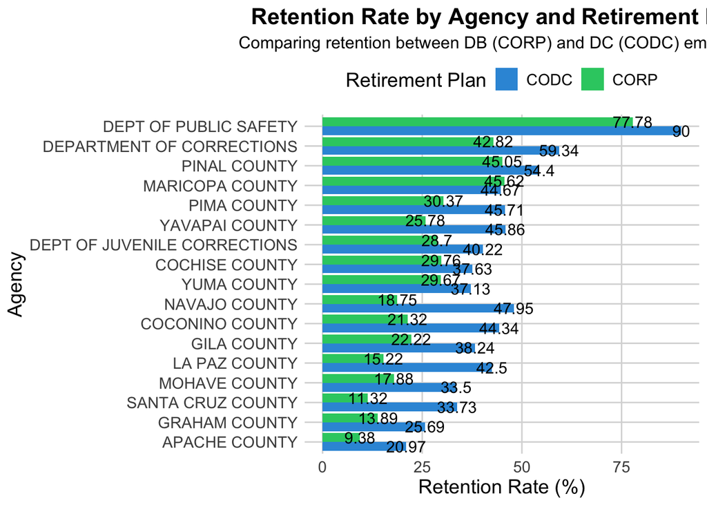

```r
# Load necessary library
library(ggplot2)

# Create a grouped bar chart with labels inside the bars
ggplot(retention_by_agency_plan, aes(x = reorder(employer_name, retention_rate), y = retention_rate, fill = pln_acronym)) +
  geom_col(position = "dodge") +  # Grouped bars for each retirement plan
  geom_text(aes(label = retention_rate),
            position = position_dodge(width = 0.9),
            vjust = 0.5,  # Move text inside the bar
            size = 4,
            color = "black") +  # White text for better contrast
  scale_fill_manual(values = c("CORP" = "#2ECC71", "CODC" = "#3498DB")) +  # Custom colors for DB vs. DC
  labs(
    title = "Retention Rate by Agency and Retirement Plan",
    subtitle = "Comparing retention between DB (CORP) and DC (CODC) employees",
    x = "Agency",
    y = "Retention Rate (%)",
    fill = "Retirement Plan"
  ) +
  coord_flip() +  # Flip for better readability
  theme_minimal() +
  theme(
    text = element_text(size = 14),
    plot.title = element_text(face = "bold", size = 16, hjust = 0.5),
    plot.subtitle = element_text(size = 12, hjust = 0.5),
    legend.position = "top",
    panel.grid.major = element_line(color = "gray85"),
    panel.grid.minor = element_blank()
  )
```